# Hw8

Calvin Wong

4/19/2020

7.2. Friedman (1991) introduced several benchmark data sets create by simulation. One of these simulations used the following nonlinear equation to create data: y = 10 sin(πx1x2) + 20(x3 − 0.5)2 + 10x4 + 5x5 + N(0, σ2) where the x values are random variables uniformly distributed between [0, 1] (there are also 5 other non-informative variables also created in the simulation). The package mlbench contains a function called mlbench.friedman1 that simulates these data:

```r
library(mlbench)
library(caret)
library(dplyr)
library(knitr)
library(AppliedPredictiveModeling)
library(RANN)
```

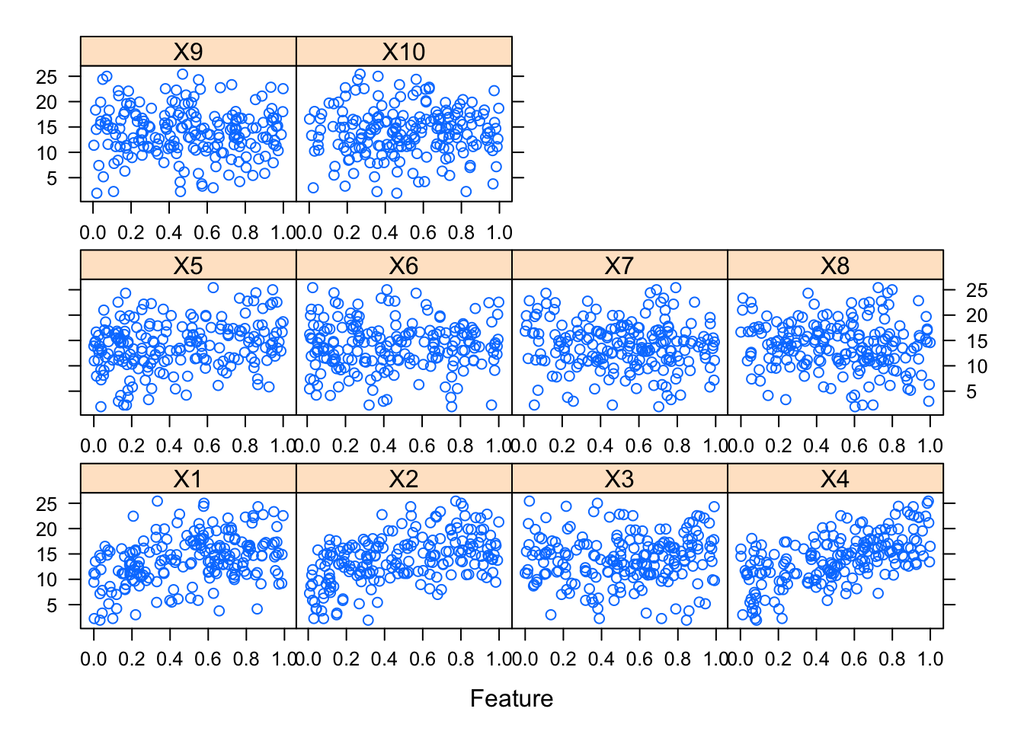

```r
set.seed(17)
trainingData <- mlbench.friedman1(200, sd = 1)
## We convert the 'x' data from a matrix to a data frame
## One reason is that this will five the columns names.
trainingData$x <- data.frame(trainingData$x)
## Look at the data using
featurePlot(trainingData$x, trainingData$y)
```

```r
testData <- mlbench.friedman1(5000, sd = 1)
testData$x <- data.frame(testData$x)
```

### KNN

```r
knnModel <- train(x = trainingData$x,
                  y = trainingData$y,
                  method = "knn",
                  preProcess = c("center", "scale"),
                  tuneLength = 10)
knnModel
```

```
## k-Nearest Neighbors
##
## 200 samples
##  10 predictor
##
## Pre-processing: centered (10), scaled (10)
## Resampling: Bootstrapped (25 reps)
## Summary of sample sizes: 200, 200, 200, 200, 200, 200, ...
## Resampling results across tuning parameters:
##
##   k   RMSE      Rsquared   MAE
##    5  3.566786  0.4517548  2.863651
##    7  3.471115  0.4882299  2.789483
##    9  3.459649  0.5031929  2.771381
##   11  3.427170  0.5294173  2.750402
##   13  3.415426  0.5462851  2.741905
##   15  3.445429  0.5487910  2.762912
##   17  3.448334  0.5620955  2.759880
##   19  3.477633  0.5650606  2.769057
##   21  3.499244  0.5687810  2.781840
##   23  3.520294  0.5726484  2.804890
##
## RMSE was used to select the optimal model using the smallest value.
## The final value used for the model was k = 13.
```

```r
knnPred <- predict(knnModel, newdata = testData$x)
## The function 'postResample' can be used to get the test set
## performance values
postResample(pred = knnPred, obs = testData$y)
```

```
##      RMSE  Rsquared       MAE
## 3.4736930 0.6258534 2.7967549
```

### MARS

```r
MARS_grid <- expand.grid(.degree = 1:2, .nprune = 2:15)
MARS_model <- train(x = trainingData$x,
                  y = trainingData$y,
                  method = "earth",
                  tuneGrid = MARS_grid,
                  preProcess = c("center", "scale"),
                  tuneLength = 10)
MARS_model
```

```
## Multivariate Adaptive Regression Spline
##
## 200 samples
##  10 predictor
##
## Pre-processing: centered (10), scaled (10)
## Resampling: Bootstrapped (25 reps)
## Summary of sample sizes: 200, 200, 200, 200, 200, 200, ...
## Resampling results across tuning parameters:
##
##   degree  nprune  RMSE      Rsquared   MAE
##   1        2      3.907480  0.3271432  3.217861
##   1        3      3.114618  0.5682832  2.481644
##   1        4      2.578390  0.7004664  2.055018
##   1        5      2.299979  0.7572127  1.833067
```

[output cut: 27 more lines]

The optimal MARS model is as follows ~ 2 Degree and 14 nprune, for the following RMSE 1.265418

```r
MARS_predictions <- predict(MARS_model, newdata = testData$x)
postResample(pred = MARS_predictions, obs = testData$y)
```

```
##      RMSE  Rsquared       MAE
## 1.1426263 0.9483259 0.9097099
```

Variable of importance

```r
varImp(MARS_model)
```

```
## earth variable importance
##
##     Overall
## X4   100.00
## X2    80.13
## X1    60.10
## X5    46.76
## X3    39.93
## X8     0.00
## X10    0.00
## X9     0.00
## X6     0.00
## X7     0.00
```

### SVM Model

```r
SVM_model <- train(x = trainingData$x,
                   y = trainingData$y,
                   method = "svmRadial",
                   preProcess = c("center", "scale"),
                   tuneLength = 10,
                   trControl = trainControl(method = "cv"))
SVM_model
```

```
## Support Vector Machines with Radial Basis Function Kernel
##
## 200 samples
##  10 predictor
##
## Pre-processing: centered (10), scaled (10)
## Resampling: Cross-Validated (10 fold)
## Summary of sample sizes: 180, 180, 180, 180, 180, 180, ...
## Resampling results across tuning parameters:
##
##   C       RMSE      Rsquared   MAE
##     0.25  2.629255  0.7639519  2.091393
##     0.50  2.363551  0.7755389  1.874241
##     1.00  2.241944  0.7873132  1.779463
##     2.00  2.144069  0.8030895  1.719183
##     4.00  2.055652  0.8187844  1.644708
##     8.00  2.029442  0.8199692  1.614403
##    16.00  2.039405  0.8172560  1.624905
##    32.00  2.039405  0.8172560  1.624905
##    64.00  2.039405  0.8172560  1.624905
##   128.00  2.039405  0.8172560  1.624905
##
## Tuning parameter 'sigma' was held constant at a value of 0.06877805
## RMSE was used to select the optimal model using the smallest value.
## The final values used for the model were sigma = 0.06877805 and C = 8.
```

```r
SVM_predictions <- predict(SVM_model, newdata = testData$x)
postResample(pred = SVM_predictions, obs = testData$y)
```

```
##      RMSE  Rsquared       MAE
## 2.2546757 0.8025172 1.7545189
```

Variable of importance

```r
varImp(SVM_model)
```

```
## loess r-squared variable importance
##
##     Overall
## X4  100.000
## X2   78.497
## X1   47.657
## X5   14.335
## X3    7.601
## X8    4.988
## X9    3.972
## X7    3.883
## X10   1.737
## X6    0.000
```

### Neural Network Model

```r
nnet_grid <- expand.grid(.decay = c(0, 0.01, .1), .size = c(1:10), .bag = FALSE)
nnet_maxnwts <- 5 * (ncol(trainingData$x) + 1) + 5 + 1
nnet_model <- train(x = trainingData$x,
                    y = trainingData$y,
                    method = "avNNet",
                    preProcess = c("center", "scale"),
                    tuneGrid = nnet_grid,
                    trControl = trainControl(method = "cv"),
                    linout = TRUE,
                    trace = FALSE,
                    MaxNWts = nnet_maxnwts,
                    maxit = 500)
nnet_model
```

```
## Model Averaged Neural Network
##
## 200 samples
##  10 predictor
##
## Pre-processing: centered (10), scaled (10)
## Resampling: Cross-Validated (10 fold)
## Summary of sample sizes: 180, 180, 180, 180, 180, 180, ...
## Resampling results across tuning parameters:
##
##   decay  size  RMSE      Rsquared   MAE
##   0.00    1    2.253017  0.7832445  1.836727
##   0.00    2    2.181335  0.7968461  1.750007
##   0.00    3    1.927626  0.8475668  1.523399
##   0.00    4    1.763917  0.8699919  1.408673
##   0.00    5    2.193035  0.8071539  1.664483
##   0.00    6         NaN        NaN       NaN
##   0.00    7         NaN        NaN       NaN
##   0.00    8         NaN        NaN       NaN
##   0.00    9         NaN        NaN       NaN
##   0.00   10         NaN        NaN       NaN
##   0.01    1    2.252248  0.7844865  1.836959
##   0.01    2    2.168499  0.7992884  1.748957
##   0.01    3    1.984978  0.8346378  1.551759
##   0.01    4    1.869558  0.8524232  1.465378
##   0.01    5    1.956710  0.8428117  1.556854
##   0.01    6         NaN        NaN       NaN
##   0.01    7         NaN        NaN       NaN
##   0.01    8         NaN        NaN       NaN
##   0.01    9         NaN        NaN       NaN
##   0.01   10         NaN        NaN       NaN
##   0.10    1    2.272289  0.7827816  1.859306
##   0.10    2    2.219241  0.7925103  1.797102
##   0.10    3    1.995132  0.8344055  1.613255
##   0.10    4    1.932076  0.8464680  1.515412
##   0.10    5    1.977599  0.8405700  1.572386
##   0.10    6         NaN        NaN       NaN
##   0.10    7         NaN        NaN       NaN
##   0.10    8         NaN        NaN       NaN
##   0.10    9         NaN        NaN       NaN
##   0.10   10         NaN        NaN       NaN
##
## Tuning parameter 'bag' was held constant at a value of FALSE
## RMSE was used to select the optimal model using the smallest value.
## The final values used for the model were size = 4, decay = 0 and bag = FALSE.
```

```r
nnet_predictions <- predict(nnet_model, newdata = testData$x)
postResample(pred = nnet_predictions, obs = testData$y)
```

```
##      RMSE  Rsquared       MAE
## 2.1265073 0.8195085 1.6248914
```

Variable of importance

```r
varImp(nnet_model)
```

```
## loess r-squared variable importance
##
##     Overall
## X4  100.000
## X2   78.497
## X1   47.657
## X5   14.335
## X3    7.601
## X8    4.988
## X9    3.972
## X7    3.883
## X10   1.737
## X6    0.000
```

Summary

```r
results <- data.frame(t(postResample(pred = knnPred, obs = testData$y))) %>%
  mutate("Model" = "KNN")

results <- data.frame(t(postResample(pred = MARS_predictions, obs = testData$y))) %>%
  mutate("Model"= "MARS") %>%
  bind_rows(results)

results <- data.frame(t(postResample(pred = SVM_predictions, obs = testData$y))) %>%
  mutate("Model"= "SVM") %>%
  bind_rows(results)

results <- data.frame(t(postResample(pred = nnet_predictions, obs = testData$y))) %>%
  mutate("Model"= "Neural Network") %>%
  bind_rows(results)

results %>%
  select(Model, RMSE, Rsquared, MAE) %>%
  arrange(RMSE) %>%
  kable()
```

| Model | RMSE | Rsquared | MAE |
| --- | --- | --- | --- |
| MARS | 1.142626 | 0.9483259 | 0.9097099 |
| Neural Network | 2.126507 | 0.8195085 | 1.6248914 |
| SVM | 2.254676 | 0.8025172 | 1.7545189 |
| KNN | 3.473693 | 0.6258534 | 2.7967549 |

Which models appear to give the best performance? Does MARS select the informative predictors (those named X1–X5)?

The MARS model performed best with an RMSE of 1.142626 and it does select informative predictors from X1 to X5.

7.5. Exercise 6.3 describes data for a chemical manufacturing process. Use the same data imputation, data splitting, and pre-processing steps as before and train several nonlinear regression models.

```r
data(ChemicalManufacturingProcess)

# Make this reproducible
set.seed(42)

knn_model <- preProcess(ChemicalManufacturingProcess, "knnImpute")
df <- predict(knn_model, ChemicalManufacturingProcess)

df <- df %>%
  select_at(vars(-one_of(nearZeroVar(., names = TRUE))))

in_train <- createDataPartition(df$Yield, times = 1, p = 0.8, list = FALSE)
train_df <- df[in_train, ]
test_df <- df[-in_train, ]

pls_model <- train(
  Yield ~ ., data = train_df, method = "pls",
  center = TRUE,
  scale = TRUE,
  trControl = trainControl("cv", number = 10),
  tuneLength = 25
)

pls_model
```

```
## Partial Least Squares
##
## 144 samples
##  56 predictor
##
## No pre-processing
## Resampling: Cross-Validated (10 fold)
## Summary of sample sizes: 131, 128, 129, 130, 129, 130, ...
## Resampling results across tuning parameters:
##
##   ncomp  RMSE       Rsquared   MAE
##    1     0.8105597  0.3870201  0.6402916
##    2     1.0479854  0.4041854  0.6761522
##    3     0.8506775  0.4518019  0.6186220
##    4     0.9899077  0.4413931  0.6824685
##    5     1.0860328  0.4567596  0.7254771
##    6     1.0815260  0.4623354  0.7158246
##    7     1.1121786  0.4733488  0.7303709
##    8     1.1367148  0.4907331  0.7303531
##    9     1.0638760  0.4847806  0.7061778
##   10     1.0817905  0.4738110  0.7070099
##   11     1.1287311  0.4574234  0.7308550
##   12     1.1663083  0.4499229  0.7590789
##   13     1.1766600  0.4527784  0.7689824
##   14     1.1932738  0.4360564  0.7773723
##   15     1.2060550  0.4344410  0.7779522
##   16     1.2084605  0.4426638  0.7748421
##   17     1.2380345  0.4505110  0.7752078
##   18     1.2166700  0.4632632  0.7554639
##   19     1.2420473  0.4546712  0.7613350
##   20     1.2932374  0.4420635  0.7812884
##   21     1.3141998  0.4339967  0.7972208
##   22     1.3011699  0.4287141  0.8033853
##   23     1.3001854  0.4349306  0.8103016
##   24     1.3056859  0.4270499  0.8201018
##   25     1.3129849  0.4188654  0.8287799
##
## RMSE was used to select the optimal model using the smallest value.
## The final value used for the model was ncomp = 1.
```

1. Which nonlinear regression model gives the optimal resampling and test set performance?

### KNN

```r
knn_model <- train(
  Yield ~ ., data = train_df, method = "knn",
  center = TRUE,
  scale = TRUE,
  trControl = trainControl("cv", number = 10),
  tuneLength = 25
)
knn_model
```

```
## k-Nearest Neighbors
##
## 144 samples
##  56 predictor
##
## No pre-processing
## Resampling: Cross-Validated (10 fold)
## Summary of sample sizes: 130, 128, 129, 130, 131, 130, ...
## Resampling results across tuning parameters:
##
##   k   RMSE       Rsquared   MAE
##    5  0.7190946  0.5065744  0.5696107
##    7  0.7212149  0.5123285  0.5766946
##    9  0.7181759  0.5251080  0.5791942
##   11  0.7208651  0.5259846  0.5840432
##   13  0.7203313  0.5264380  0.5894736
##   15  0.7382443  0.5052741  0.5991740
##   17  0.7394122  0.5135893  0.6033338
##   19  0.7450380  0.5074562  0.6059122
##   21  0.7483987  0.5103890  0.6058070
##   23  0.7542605  0.5033010  0.6075769
##   25  0.7662543  0.4860187  0.6187412
##   27  0.7731658  0.4867790  0.6260379
##   29  0.7766872  0.4886446  0.6273141
##   31  0.7863109  0.4744868  0.6384374
##   33  0.7907166  0.4774173  0.6426858
##   35  0.7941926  0.4846135  0.6449617
##   37  0.8024339  0.4817338  0.6499452
##   39  0.8096784  0.4689014  0.6543678
##   41  0.8121619  0.4654917  0.6572670
##   43  0.8168251  0.4571140  0.6629039
##   45  0.8181643  0.4646729  0.6640380
##   47  0.8244584  0.4610288  0.6694065
##   49  0.8316869  0.4471585  0.6768764
##   51  0.8351317  0.4478313  0.6805056
##   53  0.8370090  0.4480090  0.6832597
##
## RMSE was used to select the optimal model using the smallest value.
## The final value used for the model was k = 9.
```

```r
knn_predictions <- predict(knn_model, test_df)

results <- data.frame(t(postResample(pred = knn_predictions, obs = test_df$Yield))) %>%
  mutate("Model"= "KNN") %>% rbind(results)
```

### MARS

```r
MARS_grid <- expand.grid(.degree = 1:2, .nprune = 2:15)

MARS_model <- train(
  Yield ~ ., data = train_df, method = "earth",
  tuneGrid = MARS_grid,
  # If the following lines are uncommented, it throws an error
  #center = TRUE,
  #scale = TRUE,
  trControl = trainControl("cv", number = 10),
  tuneLength = 25
)
MARS_model
```

```
## Multivariate Adaptive Regression Spline
##
## 144 samples
##  56 predictor
##
## No pre-processing
## Resampling: Cross-Validated (10 fold)
## Summary of sample sizes: 131, 129, 129, 128, 130, 130, ...
## Resampling results across tuning parameters:
##
##   degree  nprune  RMSE       Rsquared   MAE
##   1        2      0.7563064  0.4522913  0.6053471
##   1        3      0.6995605  0.5207936  0.5666429
##   1        4      0.7212536  0.4734363  0.5923240
##   1        5      0.7034806  0.4944216  0.5747703
```

[output cut: 27 more lines]

```r
MARS_predictions <- predict(MARS_model, test_df)

results <- data.frame(t(postResample(pred = MARS_predictions, obs = test_df$Yield))) %>%
  mutate("Model"= "MARS") %>% rbind(results)
```

### SVM

```r
SVM_model <- train(
  Yield ~ ., data = train_df, method = "svmRadial",
  center = TRUE,
  scale = TRUE,
  trControl = trainControl(method = "cv"),
  tuneLength = 25
)
SVM_model
```

```
## Support Vector Machines with Radial Basis Function Kernel
##
## 144 samples
##  56 predictor
##
## No pre-processing
## Resampling: Cross-Validated (10 fold)
## Summary of sample sizes: 131, 128, 130, 130, 131, 128, ...
## Resampling results across tuning parameters:
##
##   C           RMSE       Rsquared   MAE
##         0.25  0.7411891  0.5053075  0.5999930
##         0.50  0.6813351  0.5637845  0.5382477
##         1.00  0.6554099  0.5901093  0.5102651
##         2.00  0.6418467  0.6105004  0.5040374
##         4.00  0.6427198  0.6125828  0.5062971
##         8.00  0.6377966  0.6159097  0.5073475
##        16.00  0.6365603  0.6166936  0.5063445
##        32.00  0.6365603  0.6166936  0.5063445
##        64.00  0.6365603  0.6166936  0.5063445
##       128.00  0.6365603  0.6166936  0.5063445
##       256.00  0.6365603  0.6166936  0.5063445
##       512.00  0.6365603  0.6166936  0.5063445
##      1024.00  0.6365603  0.6166936  0.5063445
##      2048.00  0.6365603  0.6166936  0.5063445
##      4096.00  0.6365603  0.6166936  0.5063445
##      8192.00  0.6365603  0.6166936  0.5063445
##     16384.00  0.6365603  0.6166936  0.5063445
##     32768.00  0.6365603  0.6166936  0.5063445
##     65536.00  0.6365603  0.6166936  0.5063445
##    131072.00  0.6365603  0.6166936  0.5063445
##    262144.00  0.6365603  0.6166936  0.5063445
##    524288.00  0.6365603  0.6166936  0.5063445
##   1048576.00  0.6365603  0.6166936  0.5063445
##   2097152.00  0.6365603  0.6166936  0.5063445
##   4194304.00  0.6365603  0.6166936  0.5063445
##
## Tuning parameter 'sigma' was held constant at a value of 0.01486297
## RMSE was used to select the optimal model using the smallest value.
## The final values used for the model were sigma = 0.01486297 and C = 16.
```

```r
SVM_predictions <- predict(SVM_model, test_df)

results <- data.frame(t(postResample(pred = SVM_predictions, obs = test_df$Yield))) %>%
  mutate("Model"= "SVM") %>% rbind(results)
```

### NNM

```r
nnet_grid <- expand.grid(.decay = c(0, 0.01, .1), .size = c(1:10), .bag = FALSE)
nnet_maxnwts <- 5 * ncol(train_df) + 5 + 1
nnet_model <- train(
  Yield ~ ., data = train_df, method = "avNNet",
  center = TRUE,
  scale = TRUE,
  tuneGrid = nnet_grid,
  trControl = trainControl(method = "cv"),
  linout = TRUE,
  trace = FALSE,
  MaxNWts = nnet_maxnwts,
  maxit = 500
)
nnet_model
```

```
## Model Averaged Neural Network
##
## 144 samples
##  56 predictor
##
## No pre-processing
## Resampling: Cross-Validated (10 fold)
## Summary of sample sizes: 129, 130, 130, 130, 129, 129, ...
## Resampling results across tuning parameters:
##
##   decay  size  RMSE       Rsquared   MAE
##   0.00    1    0.8599310  0.3424577  0.6999285
##   0.00    2    0.8715967  0.5016029  0.6619644
##   0.00    3    0.7686235  0.4929749  0.6231330
##   0.00    4    0.7690488  0.5367571  0.6033951
##   0.00    5    0.7579818  0.5373148  0.6079964
##   0.00    6          NaN        NaN        NaN
##   0.00    7          NaN        NaN        NaN
##   0.00    8          NaN        NaN        NaN
##   0.00    9          NaN        NaN        NaN
##   0.00   10          NaN        NaN        NaN
##   0.01    1    0.8621883  0.4113284  0.6769780
##   0.01    2    0.8503663  0.4645465  0.6770965
##   0.01    3    0.8314947  0.4372166  0.6506858
##   0.01    4    0.7571444  0.5316183  0.6010741
##   0.01    5    0.6773817  0.5948430  0.5202371
##   0.01    6          NaN        NaN        NaN
##   0.01    7          NaN        NaN        NaN
##   0.01    8          NaN        NaN        NaN
##   0.01    9          NaN        NaN        NaN
##   0.01   10          NaN        NaN        NaN
##   0.10    1    0.7874719  0.4951612  0.6332134
##   0.10    2    0.7390541  0.5317353  0.5687887
##   0.10    3    0.7230260  0.5453751  0.5674435
##   0.10    4    0.6989459  0.5786624  0.5528763
##   0.10    5    0.6532750  0.6187549  0.5142870
##   0.10    6          NaN        NaN        NaN
##   0.10    7          NaN        NaN        NaN
##   0.10    8          NaN        NaN        NaN
##   0.10    9          NaN        NaN        NaN
##   0.10   10          NaN        NaN        NaN
##
## Tuning parameter 'bag' was held constant at a value of FALSE
## RMSE was used to select the optimal model using the smallest value.
## The final values used for the model were size = 5, decay = 0.1 and bag = FALSE.
```

```r
nnet_predictions <- predict(nnet_model, test_df)

results <- data.frame(t(postResample(pred = nnet_predictions, obs = test_df$Yield))) %>%
  mutate("Model"= "Neural Network") %>% rbind(results)
```

### Summary

```r
results %>%
  select(Model, RMSE, Rsquared, MAE) %>%
  arrange(RMSE) %>%
  kable()
```

| Model | RMSE | Rsquared | MAE |
| --- | --- | --- | --- |
| Neural Network | 0.5312083 | 0.7817287 | 0.4226192 |
| SVM | 0.5712027 | 0.7112468 | 0.4706546 |
| MARS | 0.5987173 | 0.6607588 | 0.4518420 |
| KNN | 0.7778477 | 0.4320989 | 0.6403570 |
| MARS | 1.1426263 | 0.9483259 | 0.9097099 |
| Neural Network | 2.1265073 | 0.8195085 | 1.6248914 |
| SVM | 2.2546757 | 0.8025172 | 1.7545189 |
| KNN | 3.4736930 | 0.6258534 | 2.7967549 |

2. Which predictors are most important in the optimal nonlinear regression model? Do either the biological or process variables dominate the list? How do the top ten important predictors compare to the top ten predictors from the optimal linear model?

Neither the biological or process variables dominate the list. As far as the split is concerned, neither variables seem to dominate the list, although for the SVM model there is an additional process model.

```r
varImp(SVM_model, 10)
```

```
## loess r-squared variable importance
##
##   only 20 most important variables shown (out of 56)
##
##                        Overall
## ManufacturingProcess32  100.00
## BiologicalMaterial06     90.09
## ManufacturingProcess36   80.76
## BiologicalMaterial03     77.56
## ManufacturingProcess13   77.43
## BiologicalMaterial02     76.77
## BiologicalMaterial12     76.24
## ManufacturingProcess09   67.83
## ManufacturingProcess31   66.29
## ManufacturingProcess17   63.74
## ManufacturingProcess06   52.03
## ManufacturingProcess33   50.65
## ManufacturingProcess11   48.64
## BiologicalMaterial11     48.23
## ManufacturingProcess29   47.88
## BiologicalMaterial04     46.80
## BiologicalMaterial01     45.81
## BiologicalMaterial08     41.81
## ManufacturingProcess30   40.94
## ManufacturingProcess12   35.95
```

```r
varImp(pls_model, 10)
```

```
## pls variable importance
##
##   only 20 most important variables shown (out of 56)
##
##                        Overall
## ManufacturingProcess32  100.00
## ManufacturingProcess36   89.85
## BiologicalMaterial06     87.78
## BiologicalMaterial02     84.59
## ManufacturingProcess09   81.43
## BiologicalMaterial03     79.86
## ManufacturingProcess13   76.77
## ManufacturingProcess33   71.12
## BiologicalMaterial12     67.07
## BiologicalMaterial08     63.11
## BiologicalMaterial01     62.80
## ManufacturingProcess06   62.77
## BiologicalMaterial04     61.83
## BiologicalMaterial11     60.95
## ManufacturingProcess12   59.89
## ManufacturingProcess17   57.96
## ManufacturingProcess11   53.90
## ManufacturingProcess04   49.20
## ManufacturingProcess28   47.33
## ManufacturingProcess02   44.30
```

3. Explore the relationships between the top predictors and the response for the predictors that are unique to the optimal nonlinear regression model. Do these plots reveal intuition about the biological or process predictors and their relationship with yield?

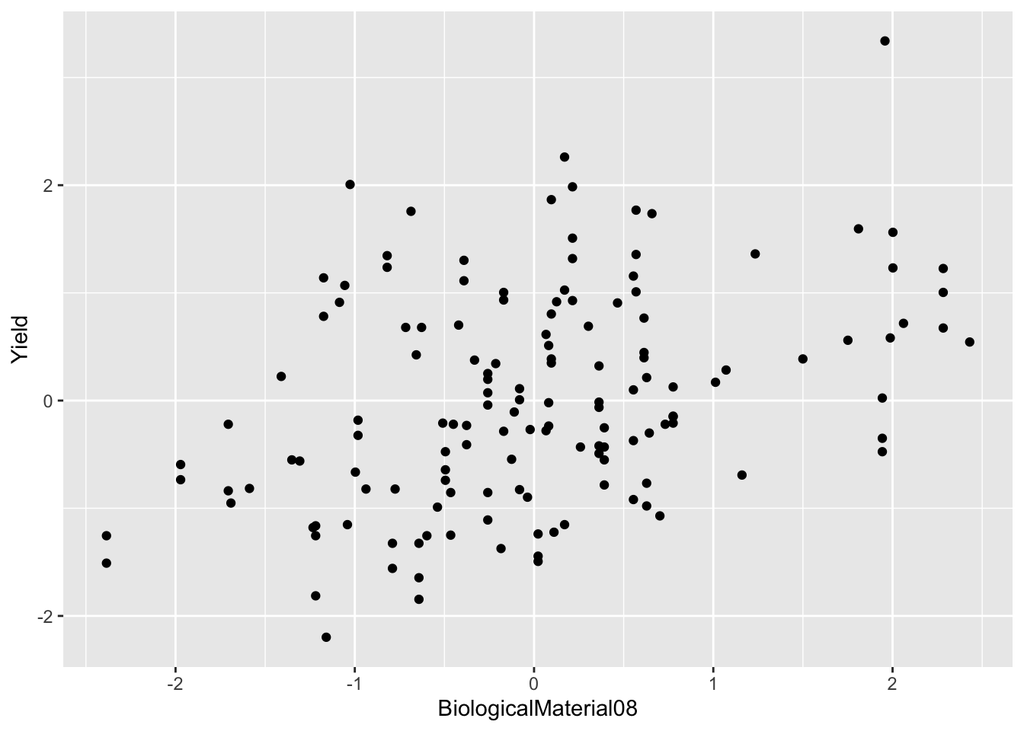

```r
ggplot(train_df, aes(BiologicalMaterial08, Yield)) +
  geom_point()
```